# Nitinat escapement 2023 (PRELIM)

South Coast StA

Last update: 2024-02-14

# 1 Infilling missing segment (2023)

On Oct 5 the section 5-4 (Eagle Pool) was not swum due to bears - a bank wank and approximation from a distance occurred.

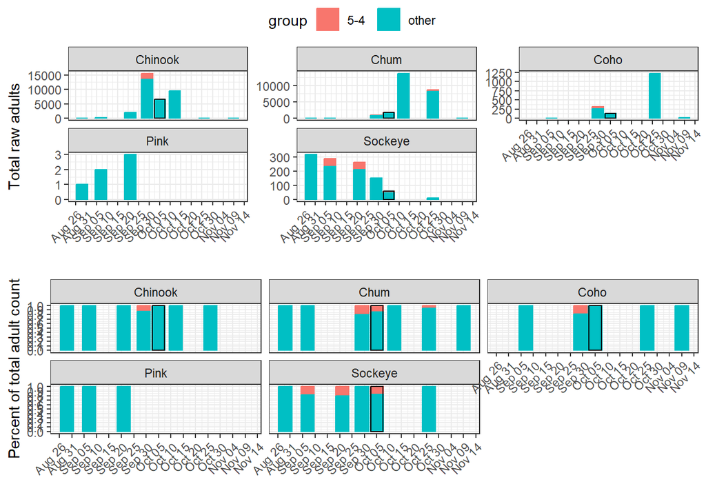

Figure: Number and proportion of counts in segment 5-4 (pink) compared to the other segments (blue) for all species. Black outline indicates the day where segment 5-4 was approximated from afar.

Notes:

- The survey following the Oct 5 incomplete survey was Oct 12, which was the flight and so had no reach-specific counts.
- The Chinook count on Oct 5 in segment 5-4 was much less than what was observed the survey before (Sept 29). In the survey before, segment 5-4 accounted for ~13% of the population (or in other words, 87% existed outside of segment 5-4). By Oct 26 there were very few Chinook left in the system. Reach 5-4 is mostly a holding area, so we would expect a few more Chinook holding in the deeper pool on Oct 5 than noted (fish would still be coming into spawn), but it is very close to Chinook spawning so they likely would have moved off into spawning grounds around this time or very soon after given the rains were already happening. **Therefore recommend applying 95% pop for Chinook**.
- The Chum count on Oct 5 in segment 5-4 is less than observed Sept 29, but not much less. In the survey before, segment 5-4 accounted for about 20% of the population (or conversely, 80% existed outside of segment 5-4). There were still fish in segment 5-4 on Oct 26, but obviously declining numbers as Chum were moving into the spawning grounds from holding pools. We would expect then that on Oct 5 there should still have been a considerable number holding, especially because they peaked the week after on the Oct 12 heli survey. **Therefore recommend applying 90% of pop to Chum**.
- The Coho count is also considerably less on Oct 5 compared to Sept 29 for segment 5-4. On Sept 29 segment 5-4 accounted for about 20% of the population (or in other words, 80% existed outside of segment 5-4). However, there were no coho in that segment Oct 26, which suggests that although Coho come into the river and hold for a long time before spawning, segment 5-4 may not be a preferred holding location, and they may shoot up to hold closer to tributaries or in even deeper pools (Eagle Pool has infilled in recent years). **Therefore recommend applying 90% of pop to Coho**.

# 2 **Sockeye**

Snorkel and heli surveys were primarily timed for Chinook and Chum. Sockeye counts are incidental and should be considered low-quality/incomplete. Very low water this summer likely resulted in a barrier to migration, preventing sockeye from reaching Parker Creek until rains came much later. For this reason, SK counts in 2023 may be much higher than previous years as they were trapped in the lower mainstem and more visible to surveyors in late August.

## 2.1 Area 21-22 raw vs expanded counts

Counts are expanded for both % population surveyed and/or observer efficiency, depending on survey conditions.

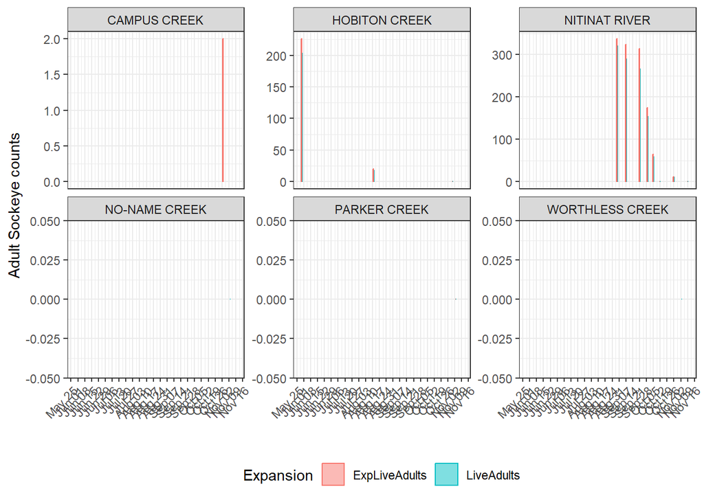

Figure: Live Adult sockeye raw counts (blue) and counts expanded for % population and/or OE (pink).

## 2.2 Counts & environmentals

Period of time log jam was impassable to sockeye in 2023.

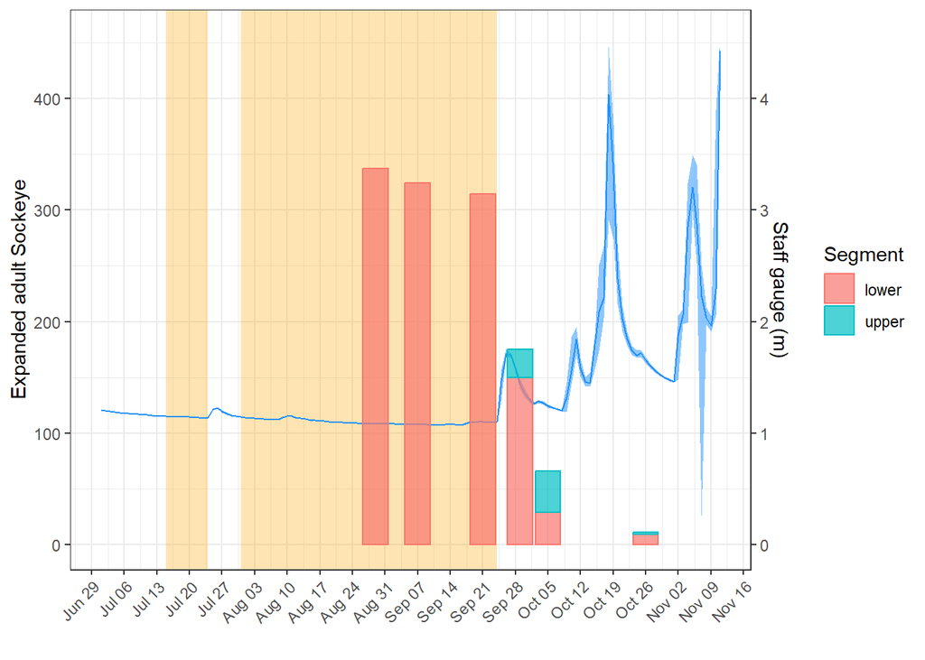

*Figure: Sockeye counts (expanded adults), water levels (blue line), and period of time water level was <1.1m (believed to be about where the log jam becomes impassable in 2023).*

## 2.3 Behaviour & carcasses

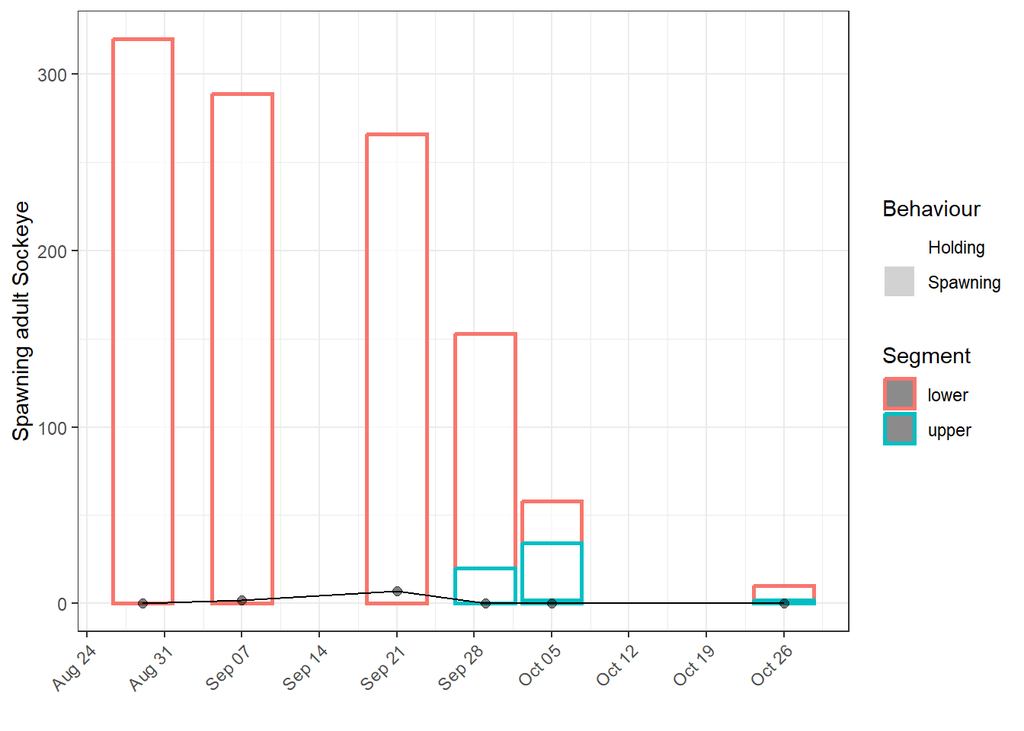

## 2.4 Snorkel & swim-in counts

There are no swim-ins for Nitinat sockeye as they are not enhanced.

## 2.5 Tributaries (River and Lake)

[output not shown]

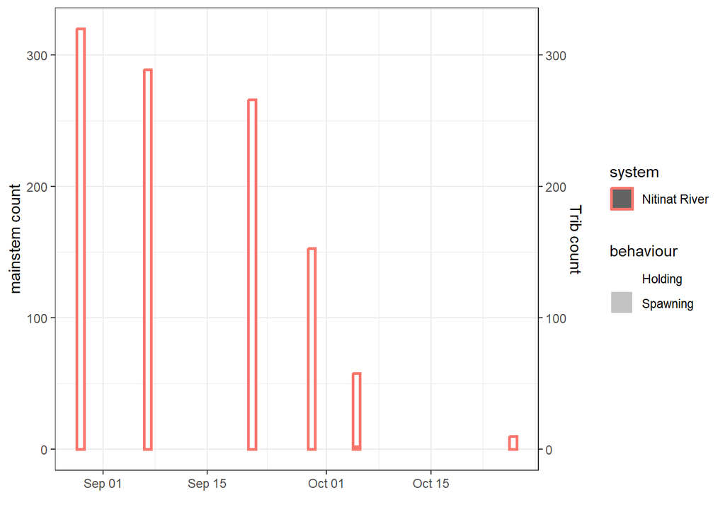

Figure: Mainstem Nitinat (pink) and trib (blue) counts for Sockeye adults (raw).

## 2.6 AUC assessments

The information below is meant to assist with determining if AUC is an appropriate method, and whether to include/exclude certain surveys.

Table: AUC math for systems receiving AUC estimate in 2023

```
## # A tibble: 8 × 13
##   WatershedCode            Year ShortSpecies DateRange NoOfDays RawAdultFishDays
##   <chr>                   <dbl> <chr>        <chr>        <dbl>            <dbl>
## 1 930-071700-00000-00000…  2023 SK           2023/07/…       36            5760
## 2 930-071700-00000-00000…  2023 SK           2023/08/…        9            2740.
## 3 930-071700-00000-00000…  2023 SK           2023/09/…       14            3885
## 4 930-071700-00000-00000…  2023 SK           2023/09/…        8            1676
## 5 930-071700-00000-00000…  2023 SK           2023/09/…        6             633
## 6 930-071700-00000-00000…  2023 SK           2023/10/…       21             714
## 7 930-071700-00000-00000…  2023 SK           2023/10/…       14              70
## 8 930-071700-00000-00000…  2023 SK           2023/11/…        6               0
## # ℹ 7 more variables: RawJackFishDays <dbl>, ExpAdultFishDays <dbl>,
## #   ExpJackFishDays <dbl>, AREA <chr>, n <int>, SystemName <chr>, method <chr>
```

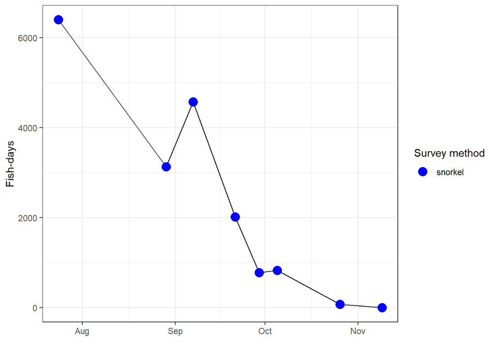

Figure: AUC curve for Nitinat mainstem Sockeye. Note in 2023 this had already excluded the heli survey, but in future would likely also include the flight for reference.

## 2.7 Area 21-22 preliminary escapement estimates

Table: Raw swim data (raw and expanded live and dead) for Sockeye.

| ShortSpecies | Section_AreaInspected | SDate | WaterTemperature | WaterClarity | LiveAdults | DeadAdults | LiveJacks | DeadJacks | ExpLiveAdults | ExpDeadAdults | ExpLiveJacks | ExpDeadJacks | OverallReliability | EstPctSeen |
| --- | --- | --- | --- | --- | --- | --- | --- | --- | --- | --- | --- | --- | --- | --- |
| SK | CAMPUS CREEK | 2023-10-27 | 6.0 | 3 - 5 m or to Bottom | 2 | NA | NA | NA | 2 | NA | NA | NA | H | 1.0 |
| SK | HOBITON CREEK | 2023-05-30 | 19.0 | 3 - 5 m or to Bottom | 203 | 0 | 0 | NA | 226 | NA | NA | NA | H | 1.0 |
| SK | HOBITON CREEK | 2023-08-11 | 17.5 | 3 - 5 m or to Bottom | 18 | 5 | 2 | NA | 20 | NA | NA | NA | H | 0.9 |
| SK | HOBITON CREEK | 2023-10-31 | 11.0 | 1 - 3 m | 0 | 0 | NA | NA | 0 | NA | NA | NA | H | 1.0 |
| SK | NITINAT RIVER | 2023-08-29 | 11.0 | 3 - 5 m or to Bottom | 320 | 0 | 4 | NA | 337 | NA | NA | NA | H | 1.0 |
| SK | NITINAT RIVER | 2023-09-07 | 10.0 | 1 - 3 m | 289 | 2 | 9 | NA | 324 | NA | NA | NA | H | 1.0 |
| SK | NITINAT RIVER | 2023-09-21 | 12.0 | 3 - 5 m or to Bottom | 266 | 7 | 0 | NA | 314 | NA | NA | NA | H | 1.0 |
| SK | NITINAT RIVER | 2023-09-29 | 12.0 | 3 - 5 m or to Bottom | 153 | 0 | 0 | NA | 175 | NA | NA | NA | H | 1.0 |
| SK | NITINAT RIVER | 2023-10-05 | 12.0 | 3 - 5 m or to Bottom | 58 | 0 | NA | NA | 65 | NA | NA | NA | H | 1.0 |
| SK | NITINAT RIVER | 2023-10-12 | 99.0 | 3 - 5 m or to Bottom | 0 | NA | NA | NA | 0 | NA | NA | NA | L | 1.0 |
| SK | NITINAT RIVER | 2023-10-26 | 6.5 | 3 - 5 m or to Bottom | 10 | 0 | 7 | NA | 11 | NA | NA | NA | M | 1.0 |
| SK | NITINAT RIVER | 2023-11-09 | 8.0 | 3 - 5 m or to Bottom | 0 | 0 | 0 | NA | 0 | NA | NA | NA | M | 1.0 |
| SK | NO-NAME CREEK | 2023-11-03 | 8.0 | 3 - 5 m or to Bottom | 0 | NA | NA | NA | NA | NA | NA | NA | H | NA |
| SK | PARKER CREEK | 2023-11-03 | 8.0 | 3 - 5 m or to Bottom | 0 | 0 | 0 | NA | 0 | NA | NA | NA | L | 1.0 |
| SK | WORTHLESS CREEK | 2023-11-03 | 8.0 | 3 - 5 m or to Bottom | 0 | NA | NA | NA | NA | NA | NA | NA | L | NA |

Table: Escapement estimates for each system.

| Year | SystemName | AREA | ShortSpecies | StartingZeroDate | EndingZeroDate | AdultShortResidenceTime | AdultMidResidenceTime_R | AdultLongResidenceTime | JackShortResidenceTime | JackMidResidenceTime_R | JackLongResidenceTime | AUCTotalDays | AdultExpAUCLowValue | AdultExpAUCMidValue_R | AdultExpAUCHighValue | JackExpAUCLowValue | JackExpAUCMidValue_R | JackExpAUCHighValue | AdultExpPLD | JackExpPLD | FinalAdultEstimate | AdultRemovalsReco | FinalJackEstimate | JackRemovalsReco | AdultRemovalsIncluded | JackRemovalsIncluded | EnumerationClass | Notes | IsFinal |
| --- | --- | --- | --- | --- | --- | --- | --- | --- | --- | --- | --- | --- | --- | --- | --- | --- | --- | --- | --- | --- | --- | --- | --- | --- | --- | --- | --- | --- | --- |
| 2023 | Nitinat River, Nitinat Lake | 22 | SK | 2023-07-24 | 2023-11-15 | 30 | 35 | 40 | 30 | 35 | 40 | 114 | 445 | 509 | 593 | 9 | 10 | 12 | 356 | 11 | 509 | 0 | 10 | 0 | FALSE | FALSE | 4 | 6 snorkel surveys Aug 29 - Nov 9. Used AUC estimate with SL=35 days. Low water was a migration barrier and likely meant sockeye were much more visible to surveyors later in the season than usual (they… | FALSE |
| 2023 | Hobiton Creek | 22 | SK | 2023-05-01 | 2023-08-31 | 15 | 20 | 25 | 15 | 20 | 25 | 184 | 529 | 662 | 882 | 8 | 10 | 13 | 226 | 2 | 226 | 0 | 2 | 0 | FALSE | FALSE | 5 | Three surveys, two of which were aimed at SK (May 30 and Aug 11); Aug 11 survey was only to assess pre-spawn mortalities and is not considered a representative estimate. 90% of population on Aug 11 du… | FALSE |
| 2023 | Campus Creek | 22 | SK | 2023-09-01 | 2023-11-15 | 15 | 20 | 25 | 15 | 20 | 25 | 0 | 0 | 0 | 0 | 0 | 0 | 0 | 2 | 0 | 0 | 0 | 0 | 0 | FALSE | FALSE | 0 | One survey of Campus Creek (Oct 27). Only swam from mouth to MC Wright marker 25 (2500m from mouth; note MC Wright markers are at 50-m intervals). | FALSE |

### 2.7.1 Estimate decision:

For 2023 used an AUC estimate with SL=35 days. Low water was a migration barrier and likely meant sockeye were much more visible to surveyors later in the season than usual (they were prevented from migrating further upstream to Parker Creek); therefore 2023 estimate may be much higher relative to previous years. Expanded escapement estimate with 35 day survey life is 509 adults + 10 jacks (519 total). Type-4 estimate due to frequent surveys, but slightly wrong time of year. Heli survey excluded. See beginning section for commentary about expansions for omission of Reach 5-4 on Oct 5 survey due to bear activity. *This is subject to change; see EscBatchHardCopy report for specific estimate abundance.*

## 2.8 2023 compared to historical run timing and abundance

Run timing information is not available for Nitinat Sockeye.

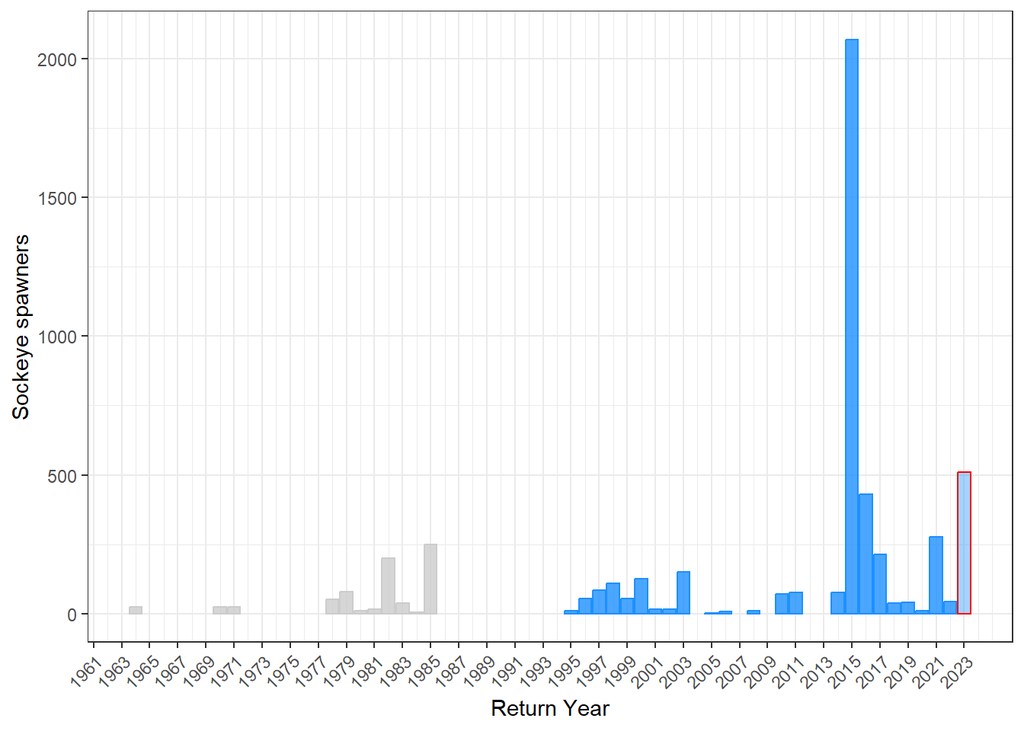

Figure: 2023 preliminary adult Sockeye escapement estimate (red outline) relative to historical adult (blue) and unspecified (gray) escapement estimates. Gaps indicate years without estimates.

# 3 **Coho**

## 3.1 Area 21-22 raw vs expanded counts

Counts are expanded for both % population surveyed and/or observer efficiency, depending on survey conditions.

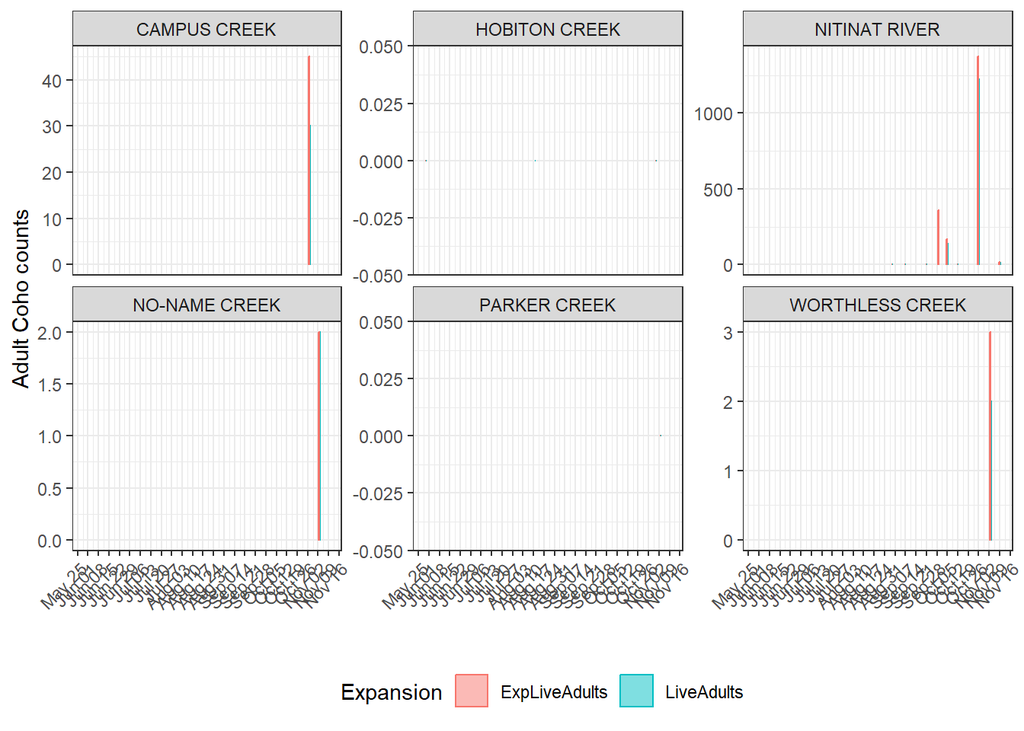

Figure: Live Adult Coho raw counts (blue) and counts expanded for % population and/or OE (pink).

## 3.2 Counts & environmentals

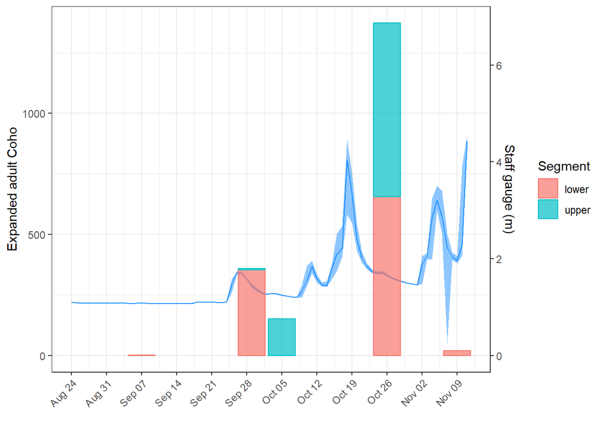

Figure: Coho counts (expanded adults) and water levels (blue line)

## 3.3 Behaviour & carcasses

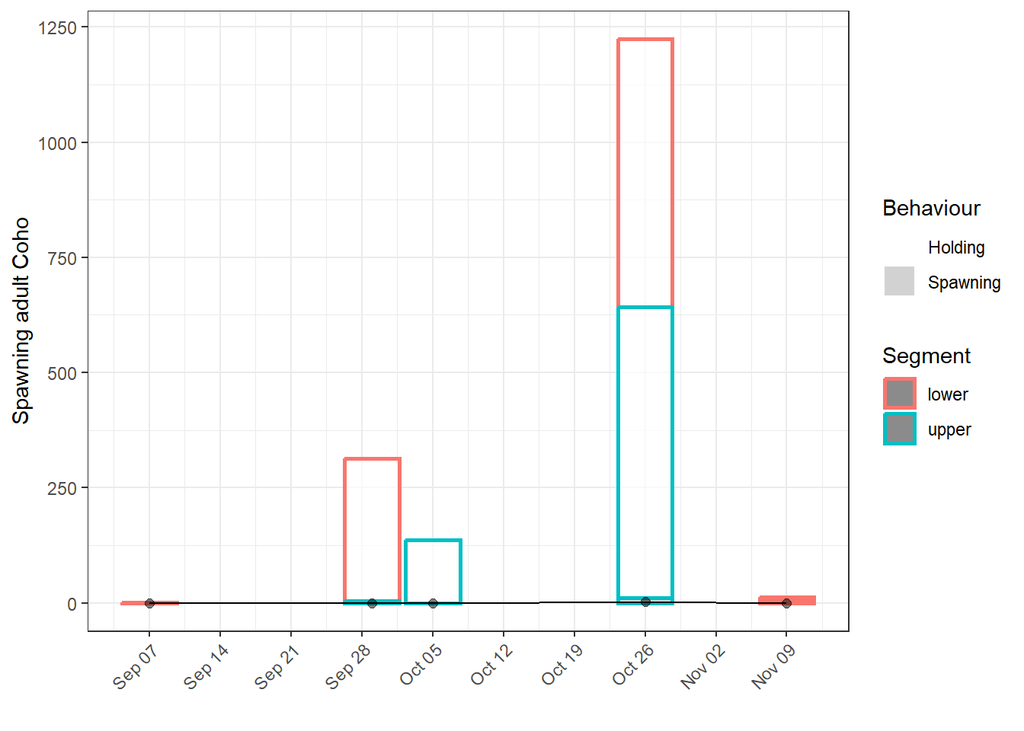

Figure: Expanded live adult Coho (bars) and carcasses (black line). Bar fill indicates behaviour (spawning=gray, holding=white), bar outline indicates river segment (upper=blue, lower=pink).

## 3.4 Snorkel & swim-in counts

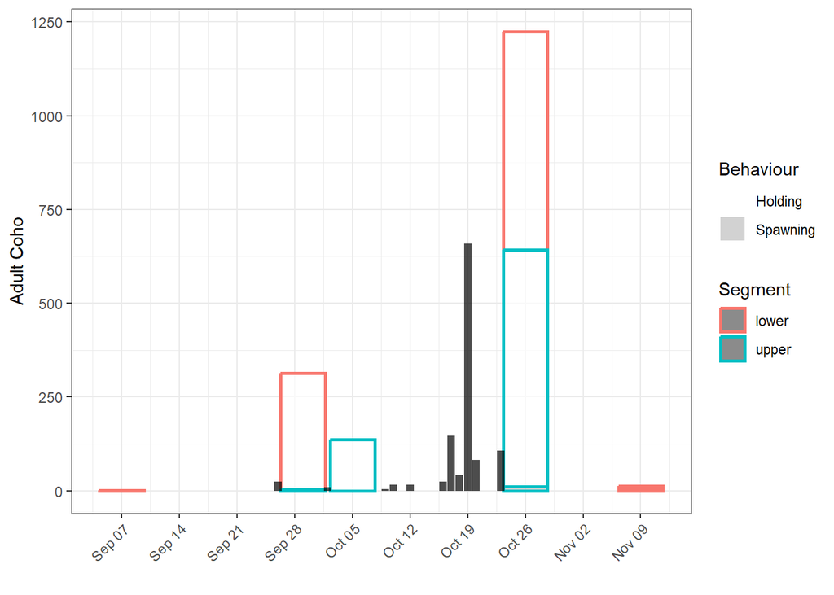

Figure: Expanded adult Coho counts (large bars) and swim-ins (narrow black bars). Adult bar fill colours indicate behaviour (spawning=gray, holding=white), bar line colour indicates river segment (lower=pink, upper=blue).

## 3.5 Tributaries (River and Lake)

Live Coho were present in Campus, NoName and Worthless Creeks in 2023.

[output not shown]

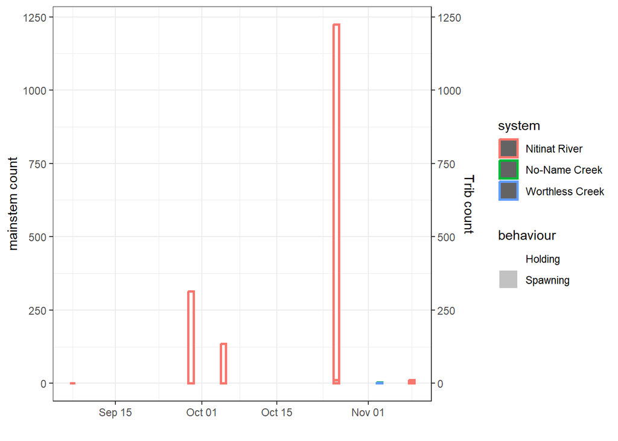

Figure: Mainstem Nitinat (pink) and trib (blue/green) counts for Coho adults (raw).

## 3.6 AUC assessments

The information below is meant to assist with determining if AUC is an appropriate method, and whether to include/exclude certain surveys.

Table: AUC math for systems receiving AUC estimate in 2023

```
## # A tibble: 8 × 13
##   WatershedCode            Year ShortSpecies DateRange NoOfDays RawAdultFishDays
##   <chr>                   <dbl> <chr>        <chr>        <dbl>            <dbl>
## 1 930-071700-00000-00000…  2023 CO           2023/08/…        1              0
## 2 930-071700-00000-00000…  2023 CO           2023/08/…        9              4.5
## 3 930-071700-00000-00000…  2023 CO           2023/09/…       14              7
## 4 930-071700-00000-00000…  2023 CO           2023/09/…        8           1256
## 5 930-071700-00000-00000…  2023 CO           2023/09/…        6           1350
## 6 930-071700-00000-00000…  2023 CO           2023/10/…       21          14290.
## 7 930-071700-00000-00000…  2023 CO           2023/10/…       14           8659
## 8 930-071700-00000-00000…  2023 CO           2023/11/…       36            216
## # ℹ 7 more variables: RawJackFishDays <dbl>, ExpAdultFishDays <dbl>,
## #   ExpJackFishDays <dbl>, AREA <chr>, n <int>, SystemName <chr>, method <chr>
```

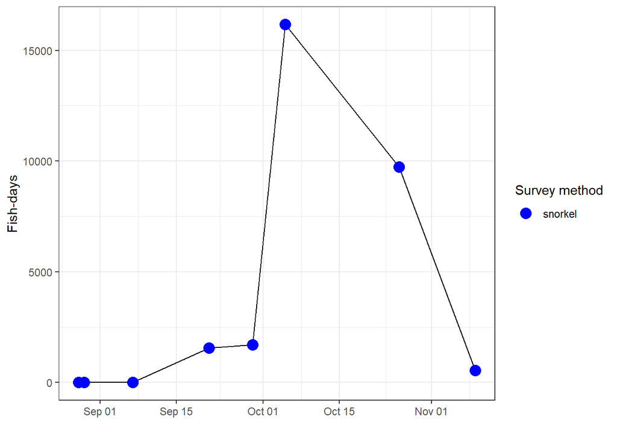

Figure: AUC curve for Nitinat mainstem Coho. Note in 2023 this had already excluded the heli survey, but in future would likely also include the flight for reference.

## 3.7 Area 21-22 preliminary escapement estimates (AUC/PL+D)

Table: Raw swim data (raw and expanded live and dead) for Coho.

| ShortSpecies | Section_AreaInspected | SDate | WaterTemperature | WaterClarity | LiveAdults | DeadAdults | LiveJacks | DeadJacks | ExpLiveAdults | ExpDeadAdults | ExpLiveJacks | ExpDeadJacks | OverallReliability | EstPctSeen |
| --- | --- | --- | --- | --- | --- | --- | --- | --- | --- | --- | --- | --- | --- | --- |
| CO | CAMPUS CREEK | 2023-10-27 | 6.0 | 3 - 5 m or to Bottom | 30 | 0 | 3 | NA | 45 | NA | NA | NA | M | 0.8 |
| CO | HOBITON CREEK | 2023-05-30 | 19.0 | 3 - 5 m or to Bottom | 0 | 0 | 0 | NA | 0 | NA | NA | NA | H | 1.0 |
| CO | HOBITON CREEK | 2023-08-11 | 17.5 | 3 - 5 m or to Bottom | 0 | NA | NA | NA | NA | NA | NA | NA | H | NA |
| CO | HOBITON CREEK | 2023-10-31 | 11.0 | 1 - 3 m | 0 | NA | NA | NA | 0 | NA | NA | NA | H | 1.0 |
| CO | NITINAT RIVER | 2023-08-29 | 11.0 | 3 - 5 m or to Bottom | 0 | 0 | 0 | NA | 0 | NA | NA | NA | H | 1.0 |
| CO | NITINAT RIVER | 2023-09-07 | 10.0 | 1 - 3 m | 1 | 0 | 0 | NA | 1 | NA | NA | NA | H | 1.0 |
| CO | NITINAT RIVER | 2023-09-21 | 12.0 | 3 - 5 m or to Bottom | 0 | NA | NA | NA | 0 | NA | NA | NA | H | 1.0 |
| CO | NITINAT RIVER | 2023-09-29 | 12.0 | 3 - 5 m or to Bottom | 314 | 0 | 0 | NA | 358 | NA | NA | NA | H | 1.0 |
| CO | NITINAT RIVER | 2023-10-05 | 12.0 | 3 - 5 m or to Bottom | 136 | 0 | NA | NA | 168 | NA | NA | NA | M | 0.9 |
| CO | NITINAT RIVER | 2023-10-12 | 99.0 | 3 - 5 m or to Bottom | 0 | NA | NA | NA | 0 | NA | NA | NA | L | 1.0 |
| CO | NITINAT RIVER | 2023-10-26 | 6.5 | 3 - 5 m or to Bottom | 1225 | 3 | 139 | NA | 1373 | NA | NA | NA | M | 1.0 |
| CO | NITINAT RIVER | 2023-11-09 | 8.0 | 3 - 5 m or to Bottom | 12 | 0 | 0 | NA | 19 | NA | NA | NA | M | 1.0 |
| CO | NO-NAME CREEK | 2023-11-03 | 8.0 | 3 - 5 m or to Bottom | 2 | 0 | 0 | NA | 2 | NA | NA | NA | H | 0.9 |
| CO | PARKER CREEK | 2023-11-03 | 8.0 | 3 - 5 m or to Bottom | 0 | 0 | 0 | NA | 0 | NA | NA | NA | L | 1.0 |
| CO | WORTHLESS CREEK | 2023-11-03 | 8.0 | 3 - 5 m or to Bottom | 2 | 0 | 0 | NA | 3 | NA | NA | NA | L | 0.9 |

Table: Escapement estimates for each system.

| Year | SystemName | AREA | ShortSpecies | StartingZeroDate | EndingZeroDate | AdultShortResidenceTime | AdultMidResidenceTime_R | AdultLongResidenceTime | JackShortResidenceTime | JackMidResidenceTime_R | JackLongResidenceTime | AUCTotalDays | AdultExpAUCLowValue | AdultExpAUCMidValue_R | AdultExpAUCHighValue | JackExpAUCLowValue | JackExpAUCMidValue_R | JackExpAUCHighValue | AdultExpPLD | JackExpPLD | FinalAdultEstimate | AdultRemovalsReco | FinalJackEstimate | JackRemovalsReco | AdultRemovalsIncluded | JackRemovalsIncluded | EnumerationClass | Notes | IsFinal |
| --- | --- | --- | --- | --- | --- | --- | --- | --- | --- | --- | --- | --- | --- | --- | --- | --- | --- | --- | --- | --- | --- | --- | --- | --- | --- | --- | --- | --- | --- |
| 2023 | Nitinat River, Nitinat Lake | 22 | CO | 2023-09-01 | 2023-12-15 | 25 | 30 | 35 | 25 | 30 | 35 | 109 | 850 | 992 | 1190 | 77 | 90 | 108 | 1364 | 154 | 1364 | 1092 | 154 | 58 | FALSE | FALSE | 4 | 6 snorkel surveys Aug 29 - Nov 9. Used PL+D as even the highest AUC estimate didn’t cover the peak raw live count and timing/coverage wasn’t great for AUC (no spawning observed). Expanded PL+D = 1364 … | FALSE |
| 2023 | Campus Creek | 22 | CO | 2023-09-01 | 2023-11-15 | 15 | 20 | 25 | 15 | 20 | 25 | 0 | 0 | 0 | 0 | 0 | 0 | 0 | 45 | 5 | 0 | 0 | 0 | 0 | FALSE | FALSE | 5 | One survey of Campus Creek (Oct 27). Only swam from mouth to MC Wright marker 25 (2500m from mouth; note MC Wright markers are at 50-m intervals). | FALSE |
| 2023 | No-Name Creek | 22 | CO | 2023-09-01 | 2023-11-15 | 15 | 20 | 25 | 15 | 20 | 25 | 0 | 0 | 0 | 0 | 0 | 0 | 0 | 2 | 0 | 0 | 0 | 0 | 0 | FALSE | FALSE | 5 | NA | FALSE |
| 2023 | Worthless Creek | 22 | CO | 2023-09-01 | 2023-11-15 | 15 | 20 | 25 | 15 | 20 | 25 | 0 | 0 | 0 | 0 | 0 | 0 | 0 | 3 | 0 | 0 | 0 | 0 | 0 | FALSE | FALSE | 5 | NA | FALSE |
| 2023 | Parker Creek, Tuck Lake | 22 | CO | 2023-09-01 | 2023-11-15 | 15 | 20 | 25 | 15 | 20 | 25 | 0 | 0 | 0 | 0 | 0 | 0 | 0 | 0 | 0 | 0 | 0 | 0 | 0 | FALSE | FALSE | 5 | NA | FALSE |

### 3.7.1 Estimate decision:

For 2023 estimate we went with PL+D as even the highest AUC estimate didn’t cover the peak raw live count and timing/coverage wasn’t great for AUC (no spawning observed). Expanded PL+D = 1364 adults + 154 jacks (1518 total). ADDED swim-ins due to survey timing relative to swim ins this year (see graph above - swim ins were already in the hatchery by the time the PL+D count happened): 1092 adult swim-ins and 58 jacks. With swim-ins added, final escapement estimate is 1364+1092 = 2456 adults + 212 jacks (2668 total). See beginning section for commentary about expansions for omission of Reach 5-4 on Oct 5 survey due to bear activity. *This is subject to change; see EscBatchHardCopy report for specific estimate abundance.*

## 3.8 2023 compared to historical run timing and abundance

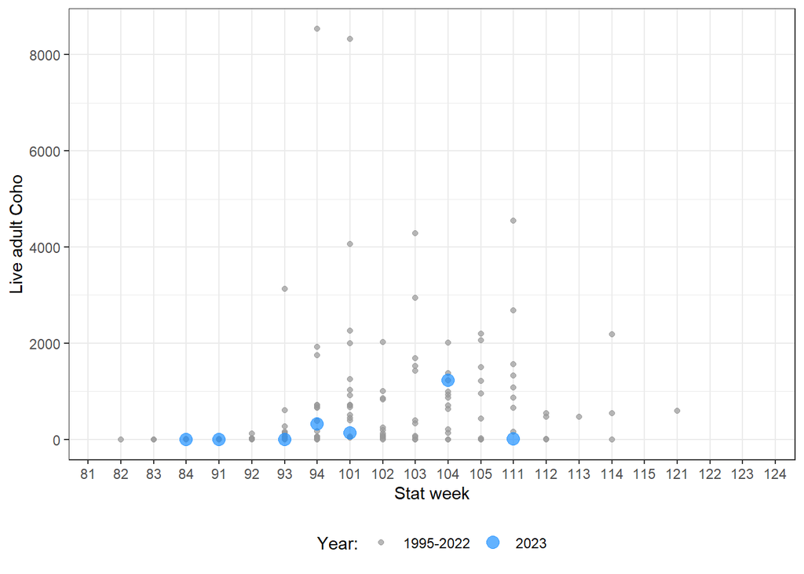

Figure: Raw swim counts (blue) from this year compared to historical raw swim counts. Stat weeks indicate the month (8=August, 12=December) and week of momth (1=first week, 2=2nd week, etc.), e.g., 81=First week of August, 91=First week of September, etc.

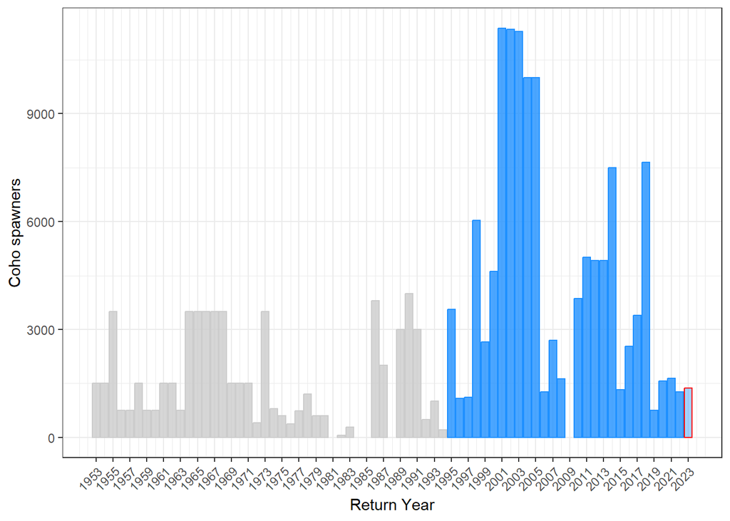

Figure: 2023 preliminary adult Coho escapement estimate (red outline) relative to historical adult (blue) and unspecified (gray) escapement estimates. Gaps indicate years without estimates.

# 4 **Chum**

Six snorkel surveys and one helicopter survey were conducted for Chum in 2023. The heli survey may have been slightly early for Chum.

## 4.1 Area 21-22 raw vs expanded counts

Counts are expanded for both % population surveyed and/or observer efficiency, depending on survey conditions.

[figure not shown]

Figure: Live Adult Chum raw counts (blue) and counts expanded for % population and/or OE (pink).

## 4.2 Counts & environmentals

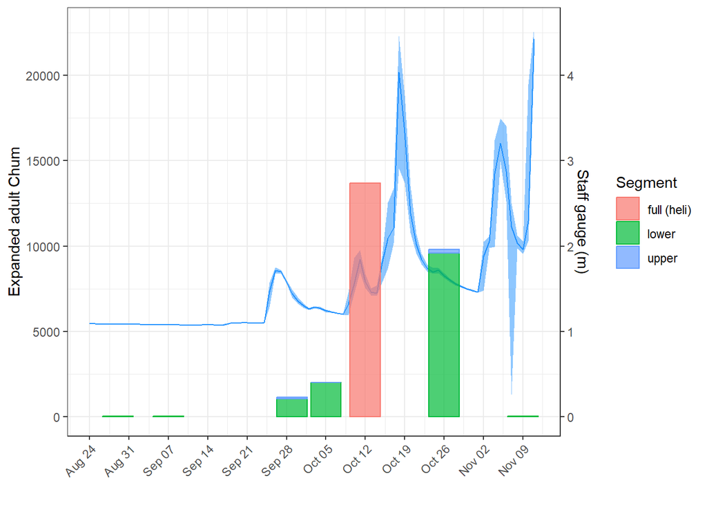

## 4.3 Behaviour & carcasses

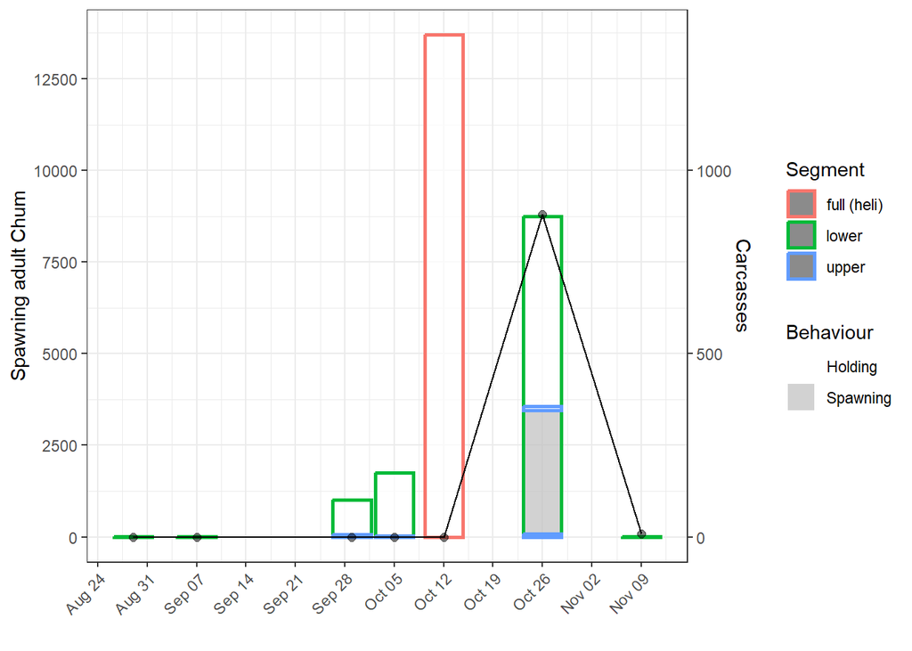

## 4.4 Snorkel & swim-in counts

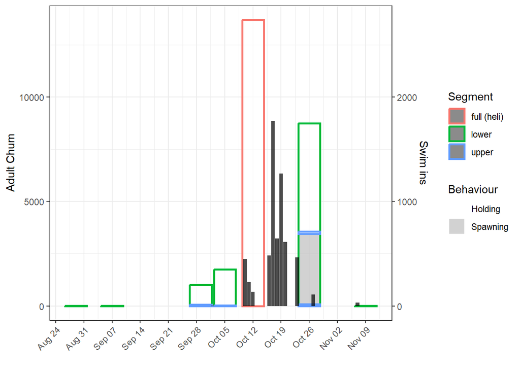

## 4.5 Tributaries (River and Lake)

Live chum were present in Campus and Hobiton Creek in 2023, and dead chum were noted in NoName Creek. Opportunistic surveys of Caycuse and Doobah found no chum.

| system | exp_ad_live | dead_adults |
| --- | --- | --- |
| Campus Creek | 698 | 175 |
| Hobiton Creek | 2681 | 18 |
| No-Name Creek | 0 | 17 |

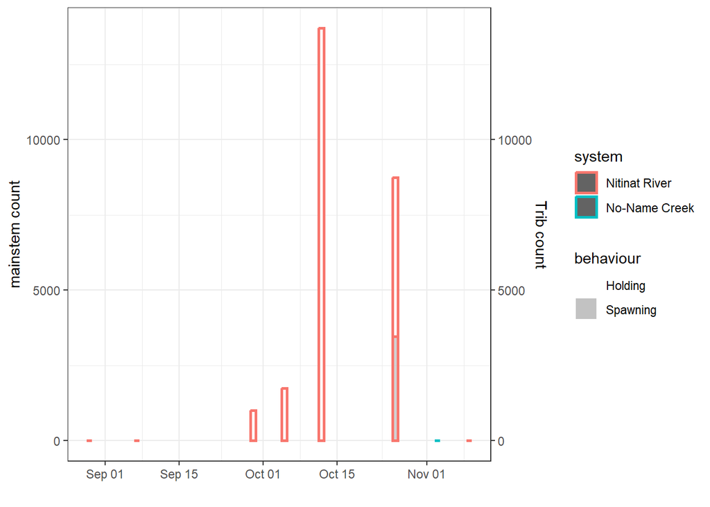

Figure: Mainstem Nitinat (pink) and trib (blue/green) counts for Chum adults (raw).

## 4.6 AUC assessments

The information below is meant to assist with determining if AUC is an appropriate method, and whether to include/exclude certain surveys.

Table: AUC math for systems receiving AUC estimate in 2023

```
## # A tibble: 9 × 13
##   WatershedCode            Year ShortSpecies DateRange NoOfDays RawAdultFishDays
##   <chr>                   <dbl> <chr>        <chr>        <dbl>            <dbl>
## 1 930-071700-00000-00000…  2023 CM           2023/08/…        4                6
## 2 930-071700-00000-00000…  2023 CM           2023/08/…        9               18
## 3 930-071700-00000-00000…  2023 CM           2023/09/…       14                7
## 4 930-071700-00000-00000…  2023 CM           2023/09/…        8             4016
## 5 930-071700-00000-00000…  2023 CM           2023/09/…        6             8250
## 6 930-071700-00000-00000…  2023 CM           2023/10/…        7            54061
## 7 930-071700-00000-00000…  2023 CM           2023/10/…       14           157115
## 8 930-071700-00000-00000…  2023 CM           2023/10/…       14            61229
## 9 930-071700-00000-00000…  2023 CM           2023/11/…        6                6
## # ℹ 7 more variables: RawJackFishDays <dbl>, ExpAdultFishDays <dbl>,
## #   ExpJackFishDays <dbl>, AREA <chr>, n <int>, SystemName <chr>, method <chr>
```

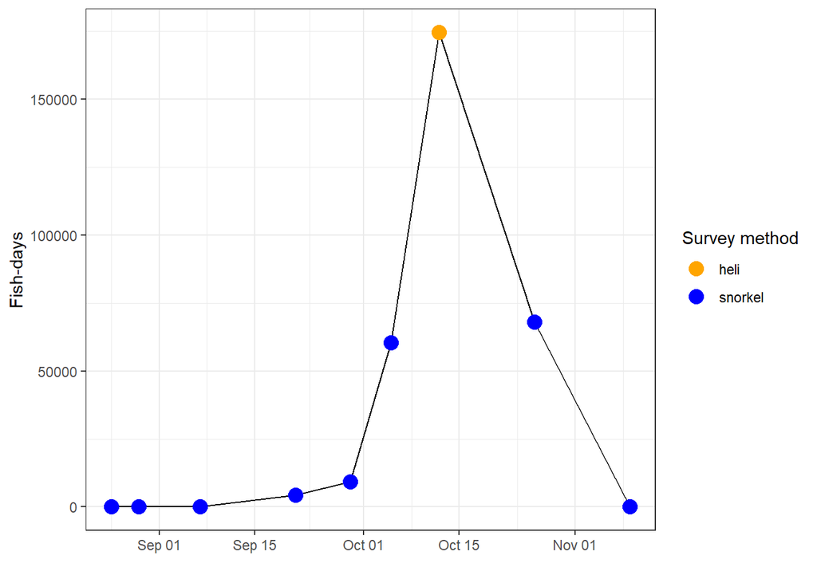

Figure: AUC curve for Nitinat mainstem Chum.

## 4.7 Area 21-22 preliminary escapement estimates (AUC)

Table: Raw swim data (raw and expanded live and dead) for Chum.

| ShortSpecies | Section_AreaInspected | SDate | WaterTemperature | WaterClarity | LiveAdults | DeadAdults | LiveJacks | DeadJacks | ExpLiveAdults | ExpDeadAdults | ExpLiveJacks | ExpDeadJacks | OverallReliability | EstPctSeen |
| --- | --- | --- | --- | --- | --- | --- | --- | --- | --- | --- | --- | --- | --- | --- |
| CM | CAMPUS CREEK | 2023-10-27 | 6.0 | 3 - 5 m or to Bottom | 626 | 175 | NA | NA | 872 | NA | NA | NA | M | 0.80 |
| CM | HOBITON CREEK | 2023-05-30 | 19.0 | 3 - 5 m or to Bottom | 0 | 0 | NA | NA | 0 | NA | NA | NA | H | 1.00 |
| CM | HOBITON CREEK | 2023-08-11 | 17.5 | 3 - 5 m or to Bottom | 0 | NA | NA | NA | NA | NA | NA | NA | H | NA |
| CM | HOBITON CREEK | 2023-10-31 | 11.0 | 1 - 3 m | 2076 | 18 | NA | NA | 3351 | NA | NA | NA | M | 0.80 |
| CM | NITINAT RIVER | 2023-08-29 | 11.0 | 3 - 5 m or to Bottom | 3 | 0 | NA | NA | 3 | NA | NA | NA | H | 1.00 |
| CM | NITINAT RIVER | 2023-09-07 | 10.0 | 1 - 3 m | 1 | 0 | NA | NA | 1 | NA | NA | NA | H | 1.00 |
| CM | NITINAT RIVER | 2023-09-21 | 12.0 | 3 - 5 m or to Bottom | 0 | NA | NA | NA | 0 | NA | NA | NA | H | 1.00 |
| CM | NITINAT RIVER | 2023-09-29 | 12.0 | 3 - 5 m or to Bottom | 1004 | 0 | NA | NA | 1108 | NA | NA | NA | H | 1.00 |
| CM | NITINAT RIVER | 2023-10-05 | 12.0 | 3 - 5 m or to Bottom | 1746 | 0 | NA | NA | 2108 | NA | NA | NA | M | 0.95 |
| CM | NITINAT RIVER | 2023-10-12 | 99.0 | 3 - 5 m or to Bottom | 13700 | NA | NA | NA | 13700 | NA | NA | NA | M | 1.00 |
| CM | NITINAT RIVER | 2023-10-26 | 6.5 | 3 - 5 m or to Bottom | 8745 | 880 | NA | NA | 9784 | NA | NA | NA | M | 1.00 |
| CM | NITINAT RIVER | 2023-11-09 | 8.0 | 3 - 5 m or to Bottom | 2 | 8 | NA | NA | 3 | NA | NA | NA | M | 1.00 |
| CM | NO-NAME CREEK | 2023-11-03 | 8.0 | 3 - 5 m or to Bottom | 0 | 17 | NA | NA | 0 | NA | NA | NA | L | 0.90 |
| CM | PARKER CREEK | 2023-11-03 | 8.0 | 3 - 5 m or to Bottom | 0 | 0 | NA | NA | 0 | NA | NA | NA | L | 1.00 |
| CM | WORTHLESS CREEK | 2023-11-03 | 8.0 | 3 - 5 m or to Bottom | 0 | NA | NA | NA | NA | NA | NA | NA | L | NA |

Table: Escapement estimates for each system.

| Year | SystemName | AREA | ShortSpecies | StartingZeroDate | EndingZeroDate | AdultShortResidenceTime | AdultMidResidenceTime_R | AdultLongResidenceTime | JackShortResidenceTime | JackMidResidenceTime_R | JackLongResidenceTime | AUCTotalDays | AdultExpAUCLowValue | AdultExpAUCMidValue_R | AdultExpAUCHighValue | JackExpAUCLowValue | JackExpAUCMidValue_R | JackExpAUCHighValue | AdultExpPLD | JackExpPLD | FinalAdultEstimate | AdultRemovalsReco | FinalJackEstimate | JackRemovalsReco | AdultRemovalsIncluded | JackRemovalsIncluded | EnumerationClass | Notes | IsFinal |
| --- | --- | --- | --- | --- | --- | --- | --- | --- | --- | --- | --- | --- | --- | --- | --- | --- | --- | --- | --- | --- | --- | --- | --- | --- | --- | --- | --- | --- | --- |
| 2023 | Nitinat River, Nitinat Lake | 22 | CM | 2023-08-25 | 2023-11-15 | 8 | 11.5 | 15 | 8 | 11.5 | 15 | 82 | 21107 | 27530 | 39575 | 0 | 0 | 0 | 15222 | 0 | 21344 | 6186 | 0 | 0 | TRUE | TRUE | 3 | 7 snorkel surveys, 3 of which were Upper+Lower (the rest were Lower) between Aug 29 - Nov 9, and one heli survey (Oct 12, retained in analysis). Used AUC estimate with mid value SL=11.5 days. Swim-ins… | FALSE |
| 2023 | Hobiton Creek | 22 | CM | 2023-09-01 | 2023-11-15 | 15 | 20.0 | 25 | 15 | 20.0 | 25 | 170 | 5536 | 6920 | 9227 | 0 | 0 | 0 | 2906 | 0 | 0 | 0 | 0 | 0 | FALSE | FALSE | 5 | One swim of Hobiton for Chum (Oct 31). Only 3/4 of system swum due to time constraints. | FALSE |
| 2023 | Campus Creek | 22 | CM | 2023-09-01 | 2023-11-15 | 15 | 20.0 | 25 | 15 | 20.0 | 25 | 0 | 0 | 0 | 0 | 0 | 0 | 0 | 1091 | 0 | 0 | 0 | 0 | 0 | FALSE | FALSE | 5 | One survey of Campus Creek (Oct 27). Only swam from mouth to MC Wright marker 25 (2500m from mouth; note MC Wright markers are at 50-m intervals). Chum abundance declined considerably after the road b… | FALSE |
| 2023 | No-Name Creek | 22 | CM | 2023-09-01 | 2023-11-15 | 15 | 20.0 | 25 | 15 | 20.0 | 25 | 0 | 0 | 0 | 0 | 0 | 0 | 0 | 19 | 0 | 0 | 0 | 0 | 0 | FALSE | FALSE | 5 | NA | FALSE |
| 2023 | Worthless Creek | 22 | CM | 2023-09-01 | 2023-11-15 | 15 | 20.0 | 25 | 15 | 20.0 | 25 | 0 | 0 | 0 | 0 | 0 | 0 | 0 | 0 | 0 | 0 | 0 | 0 | 0 | FALSE | FALSE | 5 | NA | FALSE |
| 2023 | Parker Creek, Tuck Lake | 22 | CM | 2023-09-01 | 2023-11-15 | 15 | 20.0 | 25 | 15 | 20.0 | 25 | 0 | 0 | 0 | 0 | 0 | 0 | 0 | 0 | 0 | 0 | 0 | 0 | 0 | FALSE | FALSE | 5 | NA | FALSE |

### 4.7.1 Estimate decision:

For 2023 used AUC with SL=11.5 days (mid value) to give expanded estimate of 27,530. Swim-ins need to be SUBTRACTED from this to account for fish that were likely double-counted: the peak live count occurred on the full system heli survey and therefore likely counted chum that later swam into the hatchery (see swim-in graph above). Subtracting the swim-ins for accounting (6186) leaves 21,344 chum. See beginning section for commentary about expansions for omission of Reach 5-4 on Oct 5 survey due to bear activity. *This is subject to change; see EscBatchHardCopy report for specific estimate abundance.*

## 4.8 2023 compared to historical run timing

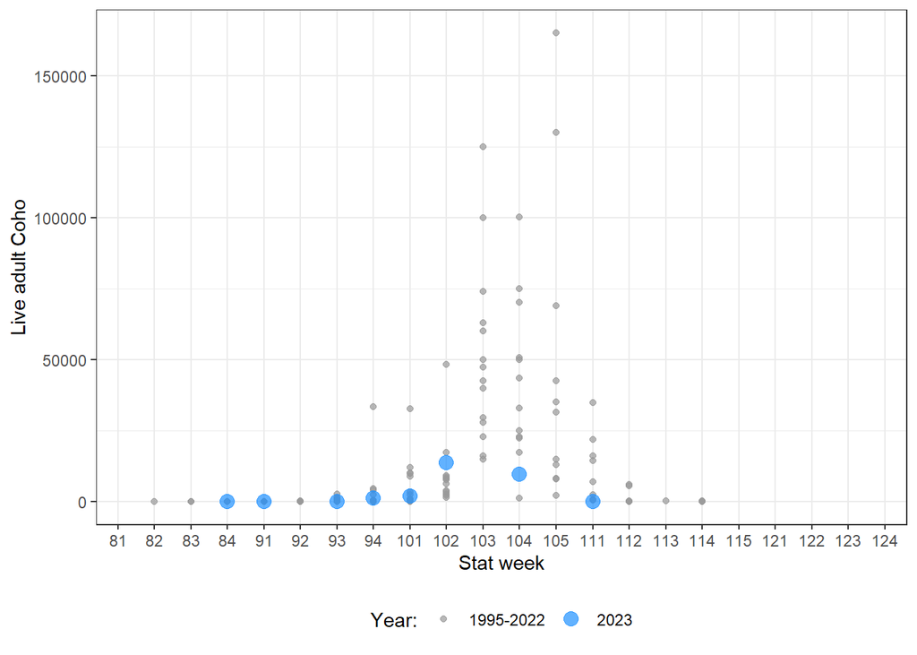

Figure: Raw swim counts (blue) from this year compared to historical raw swim counts. Stat weeks indicate the month (8=August, 12=December) and week of momth (1=first week, 2=2nd week, etc.), e.g., 81=First week of August, 91=First week of September, etc.

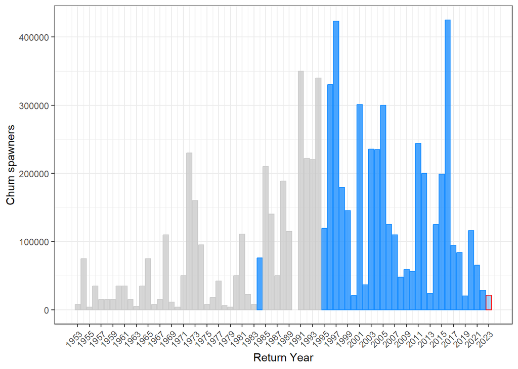

Figure: 2023 preliminary adult Chum escapement estimate (red outline) relative to historical adult (blue) and unspecified (gray) escapement estimates. There was no Chum estimate available in 1990.

# 5 **Chinook**

## 5.1 Area 21-22 raw vs expanded counts

Counts are expanded for both % population surveyed and/or observer efficiency, depending on survey conditions.

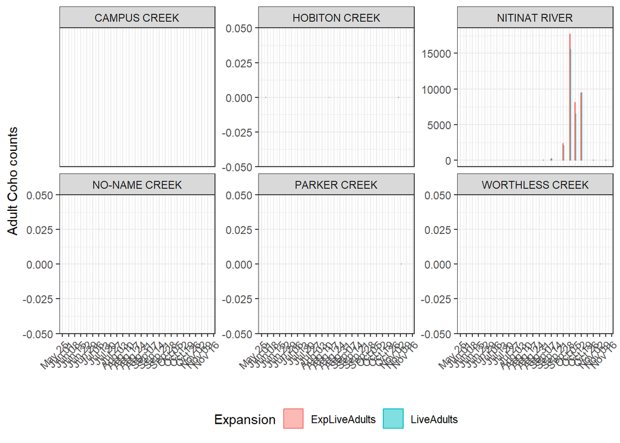

Figure: Live Adult Chinook raw counts (blue) and counts expanded for % population and/or OE (pink).

## 5.2 Counts & environmentals

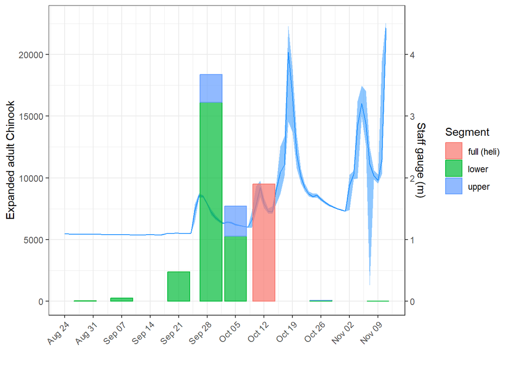

Figure: Chinook counts (expanded adults) and water levels (blue line)

## 5.3 Behaviour & carcasses

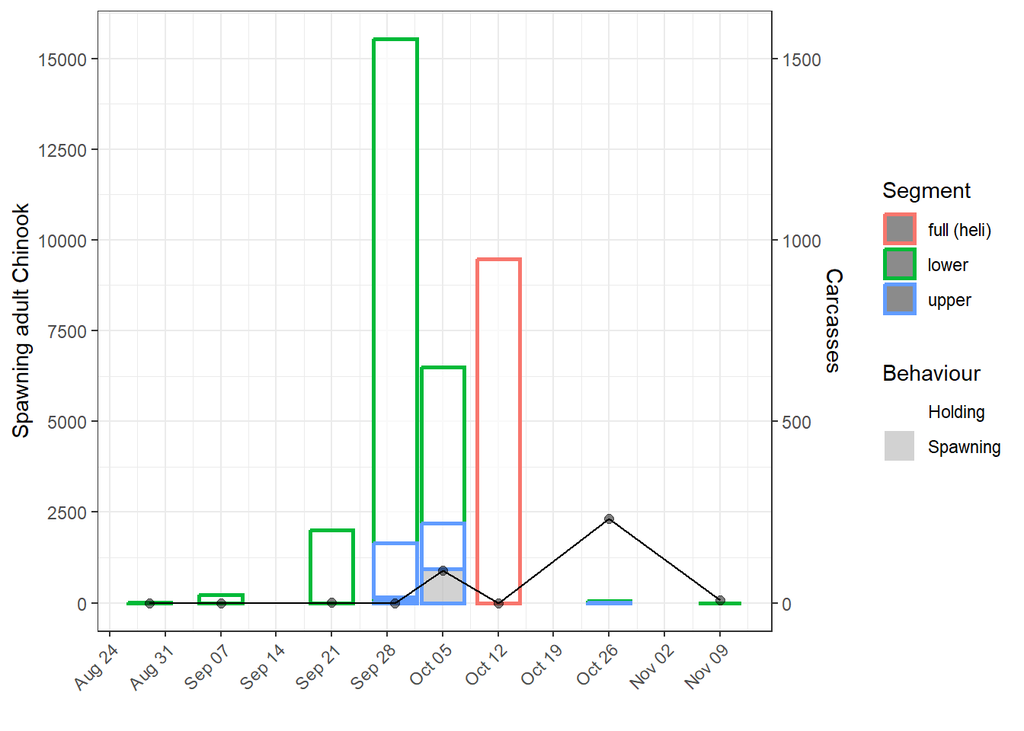

## 5.4 Snorkel & swim-in counts

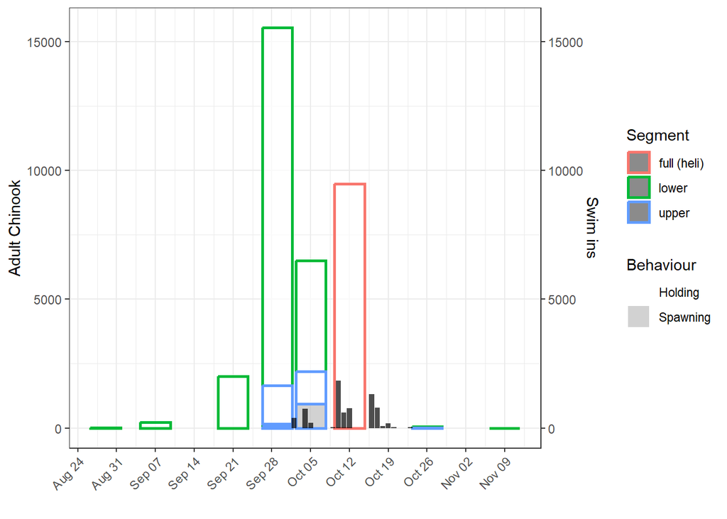

## 5.5 Tributaries (River and Lake)

Chinook were not seen in any Nitinat River or Lake tributaries in 2023.

```
## # A tibble: 0 × 20
## # ℹ 20 variables: date <dttm>, system <chr>,
## #   upper/lower (for Nitinat River only) <chr>, SIL page <dbl>, segment <chr>,
## #   % habitat seen <dbl>, species <chr>, adults live <dbl>,
## #   adults % spawning <dbl>, adults dead <dbl>, jacks live <dbl>,
## #   jacks % spawning <dbl>, jacks dead <dbl>, % new (back pg) <dbl>,
## #   adults # spawning <dbl>, adults # holding <dbl>, jacks # spawning <dbl>,
## #   jacks # holding <dbl>, adults live / habitat seen (# Est Live) <dbl>, …
```

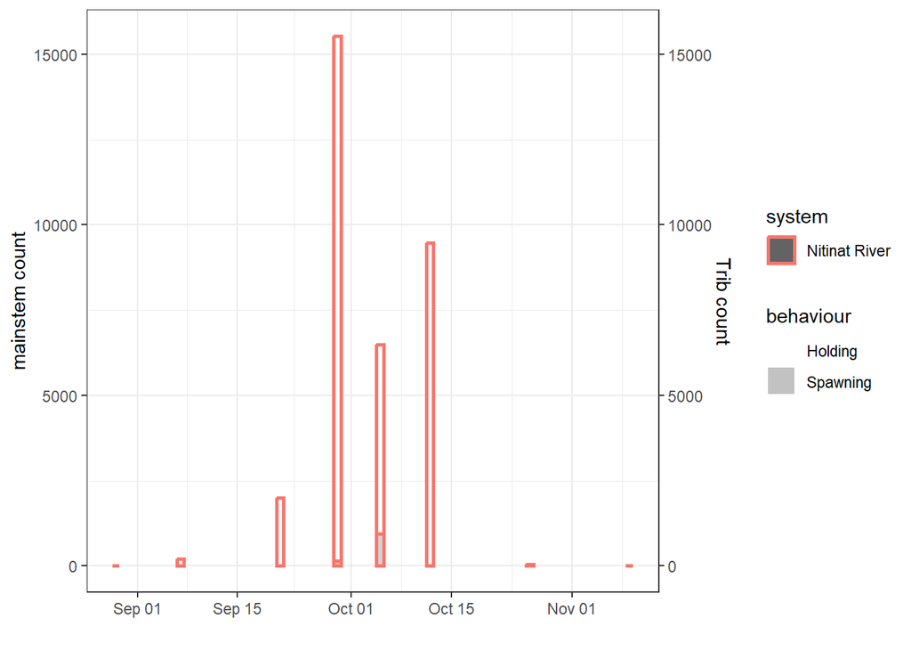

Figure: Mainstem Nitinat (pink) and trib (blue/green) counts for Chinook adults (raw).

## 5.6 AUC assessments

The information below is meant to assist with determining if AUC is an appropriate method, and whether to include/exclude certain surveys.

Table: AUC math for systems receiving AUC estimate in 2023

```
## # A tibble: 9 × 13
##   WatershedCode            Year ShortSpecies DateRange NoOfDays RawAdultFishDays
##   <chr>                   <dbl> <chr>        <chr>        <dbl>            <dbl>
## 1 930-071700-00000-00000…  2023 CN           2023/08/…       14              91
## 2 930-071700-00000-00000…  2023 CN           2023/08/…        9            1017
## 3 930-071700-00000-00000…  2023 CN           2023/09/…       14           15519
## 4 930-071700-00000-00000…  2023 CN           2023/09/…        8           70148
## 5 930-071700-00000-00000…  2023 CN           2023/09/…        6           66066
## 6 930-071700-00000-00000…  2023 CN           2023/10/…        7           55892.
## 7 930-071700-00000-00000…  2023 CN           2023/10/…       14           66689
## 8 930-071700-00000-00000…  2023 CN           2023/10/…       14             329
## 9 930-071700-00000-00000…  2023 CN           2023/11/…        6               0
## # ℹ 7 more variables: RawJackFishDays <dbl>, ExpAdultFishDays <dbl>,
## #   ExpJackFishDays <dbl>, AREA <chr>, n <int>, SystemName <chr>, method <chr>
```

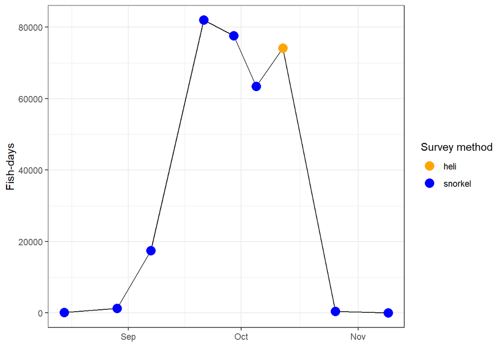

Figure: AUC curve for Nitinat mainstem Chinook.

## 5.7 Area 21-22 preliminary escapement estimates (AUC/PL+D)

Table: Raw swim data (raw and expanded live and dead) for Chinook.

| ShortSpecies | Section_AreaInspected | SDate | WaterTemperature | WaterClarity | LiveAdults | DeadAdults | LiveJacks | DeadJacks | ExpLiveAdults | ExpDeadAdults | ExpLiveJacks | ExpDeadJacks | OverallReliability | EstPctSeen |
| --- | --- | --- | --- | --- | --- | --- | --- | --- | --- | --- | --- | --- | --- | --- |
| CN | CAMPUS CREEK | 2023-10-27 | 6.0 | 3 - 5 m or to Bottom | NA | NA | NA | NA | NA | NA | NA | NA | H | NA |
| CN | HOBITON CREEK | 2023-05-30 | 19.0 | 3 - 5 m or to Bottom | 0 | 0 | 0 | NA | 0 | NA | NA | NA | H | 1.00 |
| CN | HOBITON CREEK | 2023-08-11 | 17.5 | 3 - 5 m or to Bottom | 0 | NA | NA | NA | NA | NA | NA | NA | H | NA |
| CN | HOBITON CREEK | 2023-10-31 | 11.0 | 1 - 3 m | 0 | NA | NA | NA | 0 | NA | NA | NA | H | 1.00 |
| CN | NITINAT RIVER | 2023-08-29 | 11.0 | 3 - 5 m or to Bottom | 13 | 0 | 3 | NA | 14 | NA | NA | NA | H | 1.00 |
| CN | NITINAT RIVER | 2023-09-07 | 10.0 | 1 - 3 m | 213 | 0 | 26 | NA | 225 | NA | NA | NA | H | 1.00 |
| CN | NITINAT RIVER | 2023-09-21 | 12.0 | 3 - 5 m or to Bottom | 2004 | 1 | 35 | NA | 2358 | NA | NA | NA | M | 1.00 |
| CN | NITINAT RIVER | 2023-09-29 | 12.0 | 3 - 5 m or to Bottom | 15533 | 0 | 91 | NA | 17670 | NA | NA | NA | H | 1.00 |
| CN | NITINAT RIVER | 2023-10-05 | 12.0 | 3 - 5 m or to Bottom | 6489 | 89 | 20 | NA | 8112 | NA | NA | NA | M | 0.95 |
| CN | NITINAT RIVER | 2023-10-12 | 99.0 | 3 - 5 m or to Bottom | 9480 | NA | NA | NA | 9480 | NA | NA | NA | M | 1.00 |
| CN | NITINAT RIVER | 2023-10-26 | 6.5 | 3 - 5 m or to Bottom | 47 | 231 | 0 | NA | 54 | NA | NA | NA | M | 1.00 |
| CN | NITINAT RIVER | 2023-11-09 | 8.0 | 3 - 5 m or to Bottom | 0 | 7 | 0 | NA | 0 | NA | NA | NA | M | 1.00 |
| CN | NO-NAME CREEK | 2023-11-03 | 8.0 | 3 - 5 m or to Bottom | 0 | NA | NA | NA | NA | NA | NA | NA | H | NA |
| CN | PARKER CREEK | 2023-11-03 | 8.0 | 3 - 5 m or to Bottom | 0 | 0 | 0 | NA | 0 | NA | NA | NA | L | 1.00 |
| CN | WORTHLESS CREEK | 2023-11-03 | 8.0 | 3 - 5 m or to Bottom | 0 | NA | NA | NA | NA | NA | NA | NA | L | NA |

Table: Escapement estimates for each system.

| Year | SystemName | AREA | ShortSpecies | StartingZeroDate | EndingZeroDate | AdultShortResidenceTime | AdultMidResidenceTime_R | AdultLongResidenceTime | JackShortResidenceTime | JackMidResidenceTime_R | JackLongResidenceTime | AUCTotalDays | AdultExpAUCLowValue | AdultExpAUCMidValue_R | AdultExpAUCHighValue | JackExpAUCLowValue | JackExpAUCMidValue_R | JackExpAUCHighValue | AdultExpPLD | JackExpPLD | FinalAdultEstimate | AdultRemovalsReco | FinalJackEstimate | JackRemovalsReco | AdultRemovalsIncluded | JackRemovalsIncluded | EnumerationClass | Notes | IsFinal |
| --- | --- | --- | --- | --- | --- | --- | --- | --- | --- | --- | --- | --- | --- | --- | --- | --- | --- | --- | --- | --- | --- | --- | --- | --- | --- | --- | --- | --- | --- |
| 2023 | Nitinat River, Nitinat Lake | 22 | CN | 2023-08-15 | 2023-11-15 | 15 | 20 | 25 | 15 | 20 | 25 | 92 | 12656 | 15820 | 21093 | 70 | 87 | 116 | 18274 | 107 | 14247 | 6846 | 3 | 113 | TRUE | TRUE | 3 | 7 snorkel surveys, 3 of which were Upper+Lower (the rest were Lower) between Aug 29 - Nov 9, and one heli survey (Oct 12, retained in analysis). Used AUC estimate with SL=15 days. More swim-ins than u… | FALSE |
| 2023 | No-Name Creek | 22 | CN | 2023-09-01 | 2023-11-15 | 15 | 20 | 25 | 15 | 20 | 25 | 0 | 0 | 0 | 0 | 0 | 0 | 0 | 0 | 0 | 0 | 0 | 0 | 0 | FALSE | FALSE | 5 | NA | FALSE |
| 2023 | Worthless Creek | 22 | CN | 2023-09-01 | 2023-11-15 | 15 | 20 | 25 | 15 | 20 | 25 | 0 | 0 | 0 | 0 | 0 | 0 | 0 | 0 | 0 | 0 | 0 | 0 | 0 | FALSE | FALSE | 5 | NA | FALSE |
| 2023 | Parker Creek, Tuck Lake | 22 | CN | 2023-09-01 | 2023-11-15 | 15 | 20 | 25 | 15 | 20 | 25 | 0 | 0 | 0 | 0 | 0 | 0 | 0 | 0 | 0 | 0 | 0 | 0 | 0 | FALSE | FALSE | 5 | NA | FALSE |

### 5.7.1 Estimate decision:

For 2023 estimate we went with expand AUC SL=15 for three reasons: First, there were a lot more swim-ins than usual this year, which was attributed to the COVID releases leaving the hatchery directly rather than being reared in the lake pen. Fish homing to the hatchery may have had more directed migration and therefore not did not stay in the system long. Second, the higher estimate from the shorter SL resulted in an estimate that was high enough to cover the raw peak live count of ~15k, but once removing the 6846 adult and 113 jack swim-ins, still resulted in a reasonable estimate that agreed with what the hatchery observed. Third, there may have been a slight delay in entry as the water was low for the early season and rains were a bit later than usual (though not as late as 2022). The Expanded AUC adult estimate for 2023 spawners = 21,093 adults and 116 jacks. After swim-in removal, final estimate is 14,247 adults and 3 jacks. See beginning section for commentary about expansions for omission of Reach 5-4 on Oct 5 survey due to bear activity. *This is subject to change; see EscBatchHardCopy report for specific estimate abundance.*

## 5.8 2023 compared to historical run timing and abundances

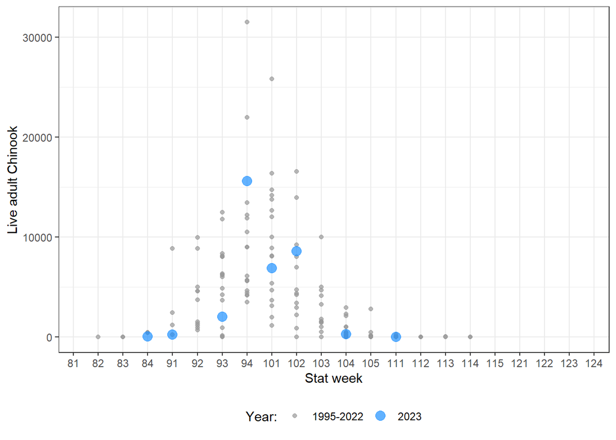

Figure: Raw swim counts (blue) from this year compared to historical raw swim counts. Stat weeks indicate the month (8=August, 12=December) and week of momth (1=first week, 2=2nd week, etc.), e.g., 81=First week of August, 91=First week of September, etc.

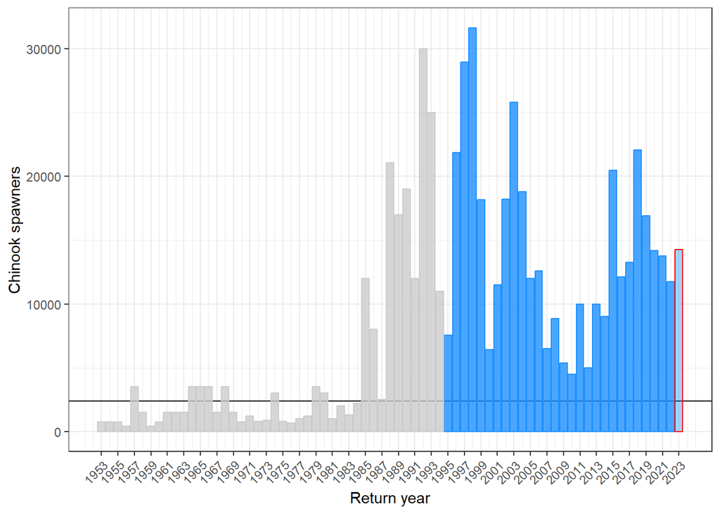

Figure: 2023 preliminary adult Chinook escapement estimate (red outline) relative to historical adult (blue) and unspecified (gray) escapement estimates.

# 6 **Pink**

No consistent WCVI pink runs.

## 6.1 Area 21-22 preliminary escapement estimates

Table: Escapement estimates for each system.

| Year | SystemName | AREA | ShortSpecies | StartingZeroDate | EndingZeroDate | AdultShortResidenceTime | AdultMidResidenceTime_R | AdultLongResidenceTime | JackShortResidenceTime | JackMidResidenceTime_R | JackLongResidenceTime | AUCTotalDays | AdultExpAUCLowValue | AdultExpAUCMidValue_R | AdultExpAUCHighValue | JackExpAUCLowValue | JackExpAUCMidValue_R | JackExpAUCHighValue | AdultExpPLD | JackExpPLD | FinalAdultEstimate | AdultRemovalsReco | FinalJackEstimate | JackRemovalsReco | AdultRemovalsIncluded | JackRemovalsIncluded | EnumerationClass | Notes | IsFinal |
| --- | --- | --- | --- | --- | --- | --- | --- | --- | --- | --- | --- | --- | --- | --- | --- | --- | --- | --- | --- | --- | --- | --- | --- | --- | --- | --- | --- | --- | --- |
| 2023 | Nitinat River, Nitinat Lake | 22 | PK | 2023-08-15 | 2023-11-15 | 15 | 20 | 25 | 15 | 20 | 25 | 92 | 3 | 4 | 5 | 0 | 0 | 0 | 4 | 0 | 4 | 0 | 0 | 0 | FALSE | FALSE | 3 | Expanded PL+D. 6 snorkel surveys Aug 29 - Nov 9. Pinks not expected. Type-3 as coverage in time/space was good. | FALSE |